# Project

Saša Cej

2023-06-16

## Structural Protein Sequences

### Sequence and meta data for various protein structures

One of the main goals of modern bioinformatics is to precisely determine the structure of proteins, which are one of the main reasons for the existence of life and are responsible for the majority of the biological processes that constantly occurs in all living organisms, from single-cellular bacteria to humans. The most important database for structural information of proteins nowadays is PDB, the “Protein Data Bank”.

The PDB archive is a repository of atomic coordinates and other information describing proteins and other important biological macromolecules. Structural biologists use methods such as X-ray crystallography, NMR spectroscopy, and cryo-electron microscopy to determine the location of each atom relative to each other in the molecule. They then deposit this information, which is then annotated and publicly released into the archive by the wwPDB.

With the two dataframes, obtained from the [kaggle database](https://www.kaggle.com/datasets/shahir/protein-data-set), I’m going to explore which is the most used technique to obtain this protein sequences and structures, how good and reliable are the obtained sequences, and I’m gonna show an overall look on the charateristcs of those sequences and molecules.

```r
library(tidyverse)
library(dplyr)
```

```r
pdb_data <- read.csv("pdb_data_no_dups.csv", header = T)
pdb_seq <- read.csv("pdb_data_seq.csv", header = T)
```

Now about the dataframes; both of them contain information of protein structures that are also present in the PDB database; in both cases, the first column, named *structureId*, stores the information on the corresponding protein in the PDB; e.g. if we take a random structureId, let’s say *3ATG*, and search it in the Protein Data Bank, we see that this is the structure of the [endo-1,3-beta-glucanase](https://www.rcsb.org/structure/3ATG) protein from *Cellulosimicrobium cellulans*. But now let’s focus on the actual dataframes that i’m gonna be working with.

> The first one is *pdb_data_no_dups.csv*, and it looks like this:

```r
head(pdb_data)
```

```
##   structureId        classification experimentalTechnique macromoleculeType
## 1        100D        DNA-RNA HYBRID     X-RAY DIFFRACTION    DNA/RNA Hybrid
## 2        101D                   DNA     X-RAY DIFFRACTION               DNA
## 3        101M      OXYGEN TRANSPORT     X-RAY DIFFRACTION           Protein
## 4        102D                   DNA     X-RAY DIFFRACTION               DNA
## 5        102L HYDROLASE(O-GLYCOSYL)     X-RAY DIFFRACTION           Protein
## 6        102M      OXYGEN TRANSPORT     X-RAY DIFFRACTION           Protein
##   residueCount resolution structureMolecularWeight
## 1           20       1.90                  6360.30
## 2           24       2.25                  7939.35
## 3          154       2.07                 18112.80
## 4           24       2.20                  7637.17
## 5          165       1.74                 18926.61
## 6          154       1.84                 18010.64
##           crystallizationMethod crystallizationTempK densityMatthews
```

[output cut: 20 more lines]

```r
summary(pdb_data)
```

```
##  structureId        classification     experimentalTechnique macromoleculeType
##  Length:141401      Length:141401      Length:141401         Length:141401
##  Class :character   Class :character   Class :character      Class :character
##  Mode  :character   Mode  :character   Mode  :character      Mode  :character
##
##
##
##
##   residueCount        resolution     structureMolecularWeight
##  Min.   :     0.0   Min.   : 0.480   Min.   :     314
##  1st Qu.:   226.0   1st Qu.: 1.800   1st Qu.:   26129
##  Median :   414.0   Median : 2.100   Median :   47478
##  Mean   :   825.4   Mean   : 2.264   Mean   :  112079
##  3rd Qu.:   820.0   3rd Qu.: 2.500   3rd Qu.:   94085
##  Max.   :313236.0   Max.   :70.000   Max.   :97730536
##                     NA's   :12812
##  crystallizationMethod crystallizationTempK densityMatthews densityPercentSol
##  Length:141401         Min.   :  4          Min.   : 0.00   Min.   : 0.00
##  Class :character      1st Qu.:290          1st Qu.: 2.21   1st Qu.:44.37
##  Mode  :character      Median :293          Median : 2.49   Median :50.50
##                        Mean   :291          Mean   : 2.67   Mean   :51.35
##                        3rd Qu.:295          3rd Qu.: 2.91   3rd Qu.:57.71
##                        Max.   :398          Max.   :99.00   Max.   :92.00
##                        NA's   :44362        NA's   :16677   NA's   :16652
##  pdbxDetails           phValue       publicationYear
##  Length:141401      Min.   :  0.00   Min.   : 201
##  Class :character   1st Qu.:  6.00   1st Qu.:2005
##  Mode  :character   Median :  7.00   Median :2010
##                     Mean   :  6.79   Mean   :2009
##                     3rd Qu.:  7.50   3rd Qu.:2014
##                     Max.   :724.00   Max.   :2018
##                     NA's   :36291    NA's   :23799
```

In this dataframe we can find informations about the techniques used to determine the structure of the biomolecules that were studied; since DNA (or RNA) and proteins are strongly connected to each other (the DNA sequence is basically the “recipe” for proteins), also the DNA or RNA were sequenced and not only proteins; still those are by far the most present in this dataframe as we can see below in the *macromoleculesType/number* tibble. Below we can also see the most used experimental technique, which is, as mentioned earlier, the x-ray diffraction, but we more different techinques and sometimes also a combination of different techinques to determine the structure of a biomolecule. We can also find useful informations about the esternal conditions that the techniques must be used for different proteins; we have the pHValue (different proteins are stable only at different pH values), the temperature (in Kelvins); then we have also informations about every single biomolecule; like the weight (structureMolecularWeight, measured in grams/mol), the resolution with which the structure was determined and the residueCount, which is basically the number of aminoacids(for proteins) or nucleotides (for DNA/RNA molecules) that are present in the structure.

```r
pdb_data %>%
  count(experimentalTechnique) %>%
  .[order(.$n, decreasing = T), ]
```

```
##                                        experimentalTechnique      n
## 30                                         X-RAY DIFFRACTION 126432
## 20                                              SOLUTION NMR  12268
## 4                                        ELECTRON MICROSCOPY   2252
## 17                                           SOLID-STATE NMR     99
## 2                                   ELECTRON CRYSTALLOGRAPHY     74
## 13                                       NEUTRON DIFFRACTION     60
## 9                                          FIBER DIFFRACTION     40
## 15                    NEUTRON DIFFRACTION, X-RAY DIFFRACTION     38
## 32                    X-RAY DIFFRACTION, NEUTRON DIFFRACTION     33
## 25                                       SOLUTION SCATTERING     32
## 16                                        POWDER DIFFRACTION     19
## 27                         SOLUTION SCATTERING, SOLUTION NMR      9
## 23                         SOLUTION NMR, SOLUTION SCATTERING      6
## 18                      SOLID-STATE NMR, ELECTRON MICROSCOPY      5
```

[output cut: 19 more lines]

```r
pdb_data %>%
  count(macromoleculeType) %>%
  .[order(.$n, decreasing = T), ]
```

```
##             macromoleculeType      n
## 6                     Protein 127798
## 7                 Protein#DNA   4176
## 1                               3765
## 11                Protein#RNA   2162
## 2                         DNA   1744
## 13                        RNA   1295
## 9             Protein#DNA#RNA    250
## 5              DNA/RNA Hybrid     58
## 4                     DNA#RNA     51
## 8  Protein#DNA#DNA/RNA Hybrid     34
## 14         RNA#DNA/RNA Hybrid     27
## 10     Protein#DNA/RNA Hybrid     19
## 3          DNA#DNA/RNA Hybrid     13
## 12 Protein#RNA#DNA/RNA Hybrid      9
```

> Now the second dataframe, *pdb_data_seq.csv*;

```r
head(pdb_seq)
```

```
##   structureId chainId
## 1        100D       A
## 2        100D       B
## 3        101D       A
## 4        101D       B
## 5        101M       A
## 6        102D       A
##                                                                                                                                                     sequence
## 1                                                                                                                                                 CCGGCGCCGG
## 2                                                                                                                                                 CCGGCGCCGG
## 3                                                                                                                                               CGCGAATTCGCG
## 4                                                                                                                                               CGCGAATTCGCG
## 5 MVLSEGEWQLVLHVWAKVEADVAGHGQDILIRLFKSHPETLEKFDRVKHLKTEAEMKASEDLKKHGVTVLTALGAILKKKGHHEAELKPLAQSHATKHKIPIKYLEFISEAIIHVLHSRHPGNFGADAQGAMNKALELFRKDIAAKYKELGYQG
## 6                                                                                                                                               CGCAAATTTGCG
##   residueCount macromoleculeType
## 1           20    DNA/RNA Hybrid
## 2           20    DNA/RNA Hybrid
## 3           24               DNA
## 4           24               DNA
## 5          154           Protein
## 6           24               DNA
```

```r
summary(pdb_seq)
```

```
##  structureId          chainId            sequence          residueCount
##  Length:467304      Length:467304      Length:467304      Min.   :     0
##  Class :character   Class :character   Class :character   1st Qu.:   456
##  Mode  :character   Mode  :character   Mode  :character   Median :  1131
##                                                           Mean   :  6173
##                                                           3rd Qu.:  4342
##                                                           Max.   :313236
##  macromoleculeType
##  Length:467304
##  Class :character
##  Mode  :character
##
##
##
```

Sidechains per structureId:

```r
pdb_seq %>%
  count(structureId) %>%
  .[order(.$n, decreasing = T), ] %>%
  head(., n = 10)
```

```
##        structureId    n
## 69706         3J3Q 1356
## 69714         3J3Y 1176
## 138888        5Y6P  862
## 111517        4V99  480
## 130762        5MQ7  360
## 136556        5V74  270
## 111345        4V4G  265
## 90741         4CTF  240
## 110422        4UDF  240
## 137250        5VYC  222
```

```r
n_distinct(pdb_seq$chainId)
```

```
## [1] 2837
```

Those two columns are the only difference with the other dataframe, since the other three are again the structureId, number of residues and the type of macromolecule that we already discussed.

> What experimental technique to use for different biomolecules?

Nowadays the structures of proteins are obtained by crystalizing the molecule and then studying the crystals; we can do that with various experimental techniques, and the most used one, as we already saw, it’s the x-ray diffraction. But for what types of molecules is it more utilized? And what about the other techniques?

1. X-RAY DIFFRACTION:

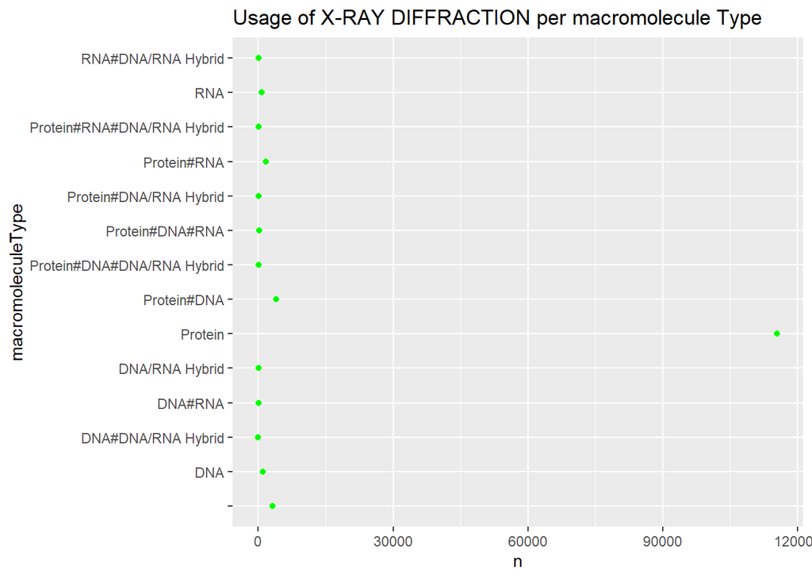

```r
pdb_data %>%
  select(experimentalTechnique, macromoleculeType) %>%
  filter(.$experimentalTechnique == 'X-RAY DIFFRACTION') %>%
  count(macromoleculeType) %>%
  .[order(.$n, decreasing = T), ] %>%
  ggplot(., aes(n, macromoleculeType)) +
  geom_point(color = 'green') +
  ggtitle("Usage of X-RAY DIFFRACTION per macromolecule Type")
```

2. SOLUTION NMR:

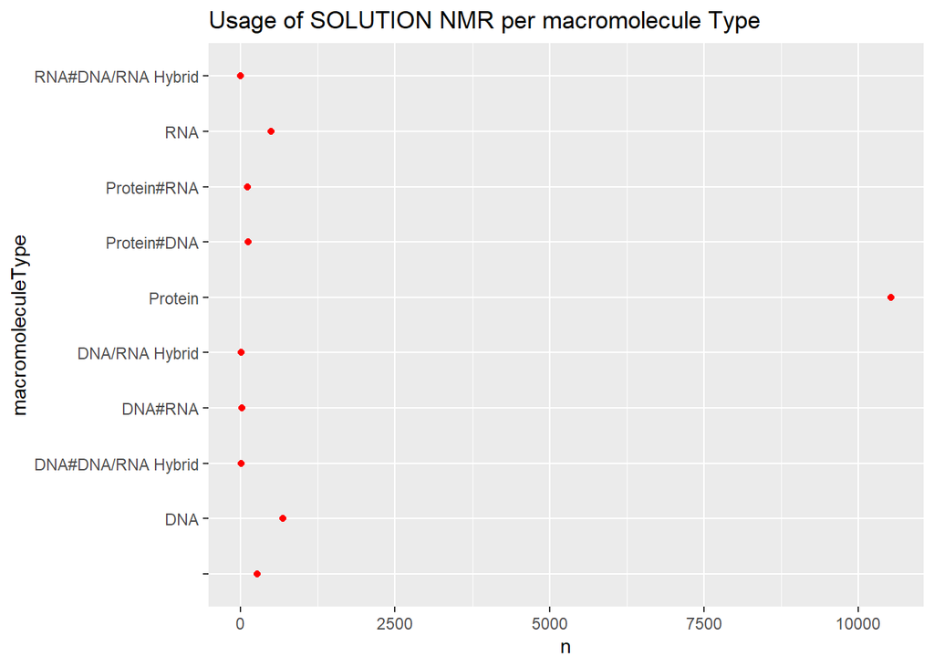

```r
pdb_data %>%
  select(experimentalTechnique, macromoleculeType) %>%
  filter(.$experimentalTechnique == 'SOLUTION NMR') %>%
  count(macromoleculeType) %>%
  .[order(.$n, decreasing = T), ] %>%
   ggplot(., aes(n, macromoleculeType)) +
  geom_point(color = 'red') +
  ggtitle("Usage of SOLUTION NMR per macromolecule Type")
```

3. ELECTRON MICROSCOPY:

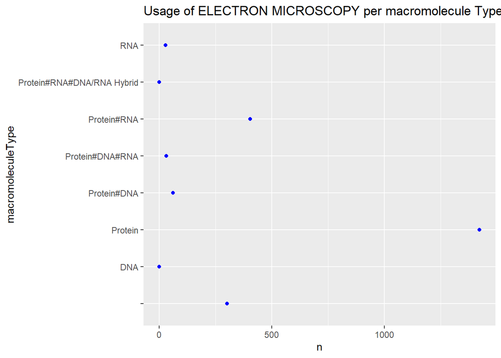

```r
pdb_data %>%
  select(experimentalTechnique, macromoleculeType) %>%
  filter(.$experimentalTechnique == 'ELECTRON MICROSCOPY') %>%
  count(macromoleculeType) %>%
  .[order(.$n, decreasing = T), ] %>%
  ggplot(., aes(n, macromoleculeType)) +
  geom_point(color = 'blue') +
   ggtitle("Usage of ELECTRON MICROSCOPY per macromolecule Type")
```

As expected all of the three most commonly used experimental techniques are mostly used to determine structures of proteins; from the graphs we can also see that they often used also to determine a protein/RNA (in the case of *ELECTRON MICROSCOPY*) and a protein/DNA (in the case of *X-RAY DIFFRACTION*) hybrid. But which of these techiques gives us the best resolution of the studied molecule?

```r
pdb_data %>%
  select(experimentalTechnique, resolution) %>%
  drop_na(experimentalTechnique, resolution) %>%
  filter(  .$experimentalTechnique == 'X-RAY DIFFRACTION'
         | .$experimentalTechnique == 'ELECTRON MICROSCOPY' ) %>%
  group_by(.$experimentalTechnique) %>%
  summarise('Average resolution' = mean(resolution),
            'Minimum (best) resolution' = min(resolution),
            'Maximum (worst) resolution' = max(resolution))
```

```
## # A tibble: 2 × 4
##   `.$experimentalTechnique` `Average resolution` Minimum (best) resolu…¹ Maxim…²
##   <chr>                                    <dbl>                   <dbl>   <dbl>
## 1 ELECTRON MICROSCOPY                       8.42                    1.8       70
## 2 X-RAY DIFFRACTION                         2.16                    0.48      15
## # … with abbreviated variable names ¹`Minimum (best) resolution`,
## #   ²`Maximum (worst) resolution`
```

In crystallography, resolution is the smallest distance between crystal lattice planes that is resolved in the diffraction pattern. That means that the lower the value, the better the resolution (*unit - armstrong: Å*). So we can clearly see that we get the best resolution with the x-ray diffraction; that’s one of the main reasons why this is by far the most used one. The difference in the mean resolution cmpared to electron microscopy is enormous.

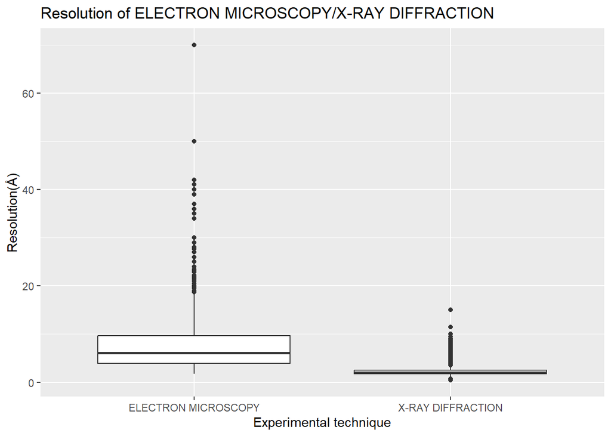

```r
pdb_data %>%
  select(experimentalTechnique, resolution) %>%
  drop_na(experimentalTechnique, resolution) %>%
  filter(  .$experimentalTechnique == 'X-RAY DIFFRACTION'
         | .$experimentalTechnique == 'ELECTRON MICROSCOPY' ) %>%
  ggplot(., aes(experimentalTechnique, resolution)) +
  geom_boxplot() +
  ggtitle("Resolution of ELECTRON MICROSCOPY/X-RAY DIFFRACTION" ) +
  labs(x = "Experimental technique", y = "Resolution(Å)")
```

> What about the size of the molecules?

Is it harder to get a good resolution with the larger molecules? Let’s take in consideration the length of the sequences; in the dataframes this equals to the residueCount column. Note also that a longer sequence of aminoacids means also a heavier molecule, so we could also look at the molecular wieght, but in this way is harder to explore the actual residues of the sequence.

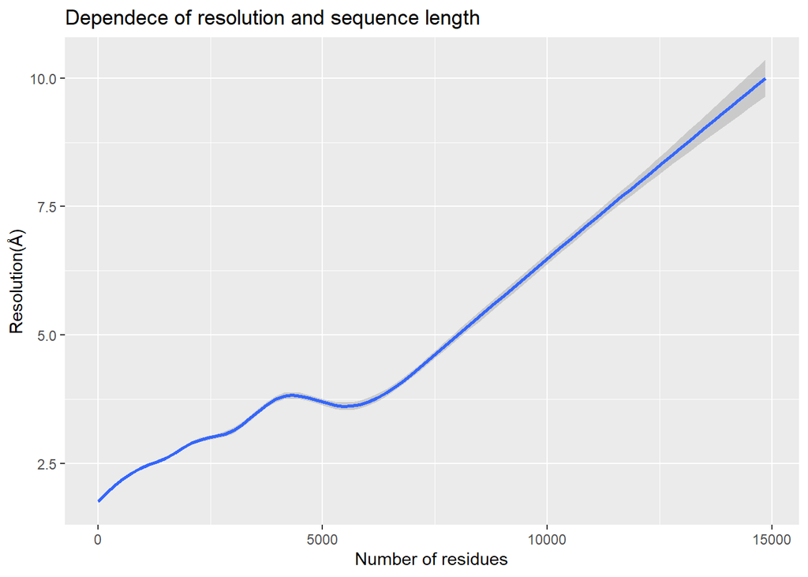

```r
pdb_data %>%
  select(residueCount, resolution) %>%
  drop_na(residueCount, resolution) %>%
  filter(.$residueCount < 15000 & .$residueCount > 0) %>%
  ggplot(., aes(residueCount, resolution)) +
  geom_smooth() +
  labs(title = "Dependece of resolution and sequence length",
       x = "Number of residues",
       y = "Resolution(Å)")
```

> Molecules (sequence length + weigth) with best resolutions:

```r
pdb_data %>%
  select(residueCount,structureMolecularWeight, resolution) %>%
  drop_na(residueCount, resolution) %>%
  filter(.$residueCount < 15000 & .$residueCount > 0) %>%
  .[order(.$resolution, decreasing = F), ] %>%
  head(., n = 10)
```

```
##        residueCount structureMolecularWeight resolution
## 63322            48                  4922.72       0.48
## 63323            48                  4922.72       0.48
## 108065           83                  9902.09       0.48
## 4606             48                  4738.45       0.54
## 65330            12                  3822.75       0.55
## 119771           54                  6244.63       0.59
## 8197             12                  3822.75       0.60
## 9358             24                  8862.30       0.61
## 20666            64                  6911.28       0.62
## 74969           180                 19908.29       0.64
```

> Molecules (sequence length + weigth) with worst resolutions:

```r
pdb_data %>%
  select(residueCount,structureMolecularWeight, resolution) %>%
  drop_na(residueCount, resolution) %>%
  filter(.$residueCount < 15000 & .$residueCount > 0) %>%
  .[order(.$resolution, decreasing = F), ] %>%
  tail(., n = 10)
```

```
##       residueCount structureMolecularWeight resolution
## 13002        12042                  1358591         70
## 14183        11750                  1326464         70
## 14184        12042                  1358591         70
## 14185        12042                  1358591         70
## 14186         9778                  1101086         70
## 14187        10910                  1229839         70
## 14188        12042                  1358591         70
## 14189        12042                  1358591         70
## 14190         9778                  1101086         70
## 14191        12042                  1358591         70
```

*Note: I escluded sequences longer than 15,000 residues since there are very few compared to the dimension of the dataframe*

As we can see the shorter/smaller molecules have (generally) the best resolution. But is the sequence length actually correlated to the quality of the resolution? By performing a Spearman’s test to our data we can confirm that they actually are correlated;

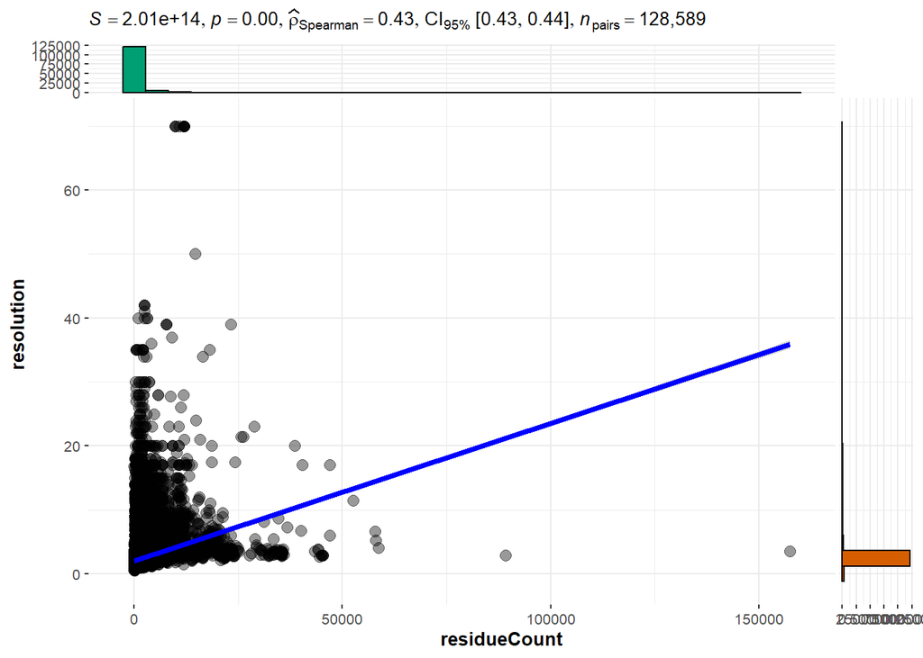

```r
library(ggstatsplot)
ggscatterstats(data = pdb_data,
               x = residueCount,
               y = resolution,
               type = "nonparametric"
               )
```

We got an extremly low *p-value*: $p = 0.00$. This means that we can accept the alternative hypotesis, that is that the number of residues of a molecule and the resolution with wich it’s structure can be determined are correlated. We got even more informations than that; the *Spearman’s coefficient*, $\rho = 0.43$. As we can see also in the above graph, the two variables are positively correlated; in other words if we encrease the length of the sequence also the resolution value will encrease; and as we already established, a higher resolution value means that the resultion gets only worst.

> X-RAY DIFFRACTION: for what molecule size is it used?

```r
pdb_data %>%
  select(experimentalTechnique, residueCount) %>%
  drop_na(experimentalTechnique, residueCount) %>%
  filter(.$experimentalTechnique == 'X-RAY DIFFRACTION'
         & .$residueCount < 15000
         & .$residueCount > 0) %>%
  group_by(.$experimentalTechnique) %>%
  summarise("Average sequence length" = mean(.$residueCount),
            "Shortest sequence" = min(.$residueCount),
            "Longest sequence" = max(.$residueCount),
            "1st quantile" = quantile(.$residueCount, 0.25),
            "Median" = quantile(.$residueCount, 0.5),
            "3rd quantile" = quantile(.$residueCount, 0.75))
```

```
## # A tibble: 1 × 7
##   `.$experimentalTechnique` Average seq…¹ Short…² Longe…³ 1st q…⁴ Median 3rd q…⁵
##   <chr>                             <dbl>   <int>   <int>   <dbl>  <dbl>   <dbl>
## 1 X-RAY DIFFRACTION                  752.       2   14864     269    454     844
## # … with abbreviated variable names ¹`Average sequence length`,
## #   ²`Shortest sequence`, ³`Longest sequence`, ⁴`1st quantile`, ⁵`3rd quantile`
```

```r
pdb_data %>%
  select(experimentalTechnique, residueCount) %>%
  filter(.$experimentalTechnique == 'X-RAY DIFFRACTION'
         & .$residueCount > 1000) %>%
  count(.$experimentalTechnique)
```

```
##   .$experimentalTechnique     n
## 1       X-RAY DIFFRACTION 24231
```

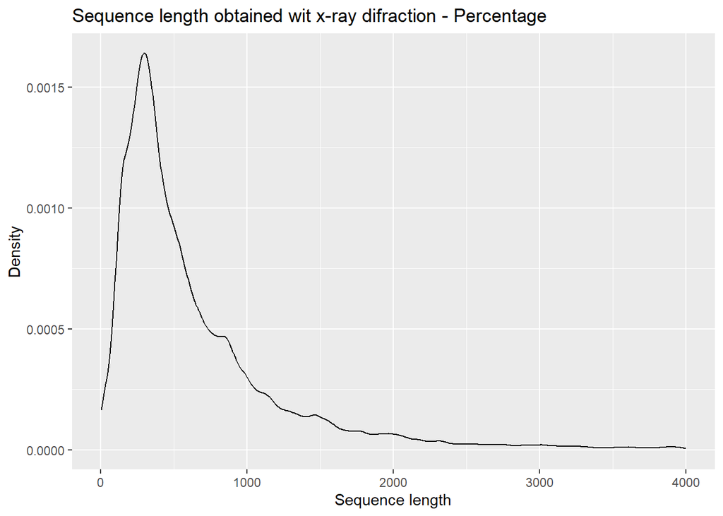

```r
pdb_data %>%
  select(experimentalTechnique, residueCount) %>%
  drop_na(experimentalTechnique, residueCount) %>%
  filter(.$experimentalTechnique == 'X-RAY DIFFRACTION'
         & .$residueCount < 4000
         & .$residueCount > 0) %>%
  ggplot(., aes(residueCount)) +
  geom_density() +
  labs(title = "Sequence length obtained wit x-ray difraction - Percentage",
       x = "Sequence length",
       y = "Density")
```

> The protein sequences obtained with x-ray diffraction

```r
pdb_data %>%
  select(structureId, experimentalTechnique) %>%
  filter(.$experimentalTechnique == 'X-RAY DIFFRACTION') %>%
  inner_join(., pdb_seq, by = "structureId") %>%
  select(structureId, sequence, chainId, residueCount, macromoleculeType) %>%
  filter(.$macromoleculeType == 'Protein') %>%
  select(structureId, sequence, chainId, residueCount) %>%
  head(., n = 10)
```

```
##    structureId
## 1         101M
## 2         102L
## 3         102M
## 4         103L
## 5         103M
## 6         104L
## 7         104L
## 8         104M
## 9         105M
## 10        106M
##                                                                                                                                                                   sequence
## 1               MVLSEGEWQLVLHVWAKVEADVAGHGQDILIRLFKSHPETLEKFDRVKHLKTEAEMKASEDLKKHGVTVLTALGAILKKKGHHEAELKPLAQSHATKHKIPIKYLEFISEAIIHVLHSRHPGNFGADAQGAMNKALELFRKDIAAKYKELGYQG
## 2    MNIFEMLRIDEGLRLKIYKDTEGYYTIGIGHLLTKSPSLNAAAKSELDKAIGRNTNGVITKDEAEKLFNQDVDAAVRGILRNAKLKPVYDSLDAVRRAALINMVFQMGETGVAGFTNSLRMLQQKRWDEAAVNLAKSRWYNQTPNRAKRVITTFRTGTWDAYKNL
## 3               MVLSEGEWQLVLHVWAKVEADVAGHGQDILIRLFKSHPETLEKFDRFKHLKTEAEMKASEDLKKAGVTVLTALGAILKKKGHHEAELKPLAQSHATKHKIPIKYLEFISEAIIHVLHSRHPGNFGADAQGAMNKALELFRKDIAAKYKELGYQG
```

[output cut: 18 more lines]

Now we have a dataframe containing all the sequences from proteins that were obtained using the x-ray diffraction technique. We could now obtain the *.pdb* file of one or more sequences from the PDB website; with this using the package *bio3d* in r we can study the protein even more, from aligning sequences to find homolougs or other related proteins, and we can also create a contact map of how the secondary structure of this proteins looks like. Let’s take the protein with structureId 101M for this example.

```r
library(bio3d)
```

```r
get.pdb("101M")
```

```
## [1] "./101M.pdb"
```

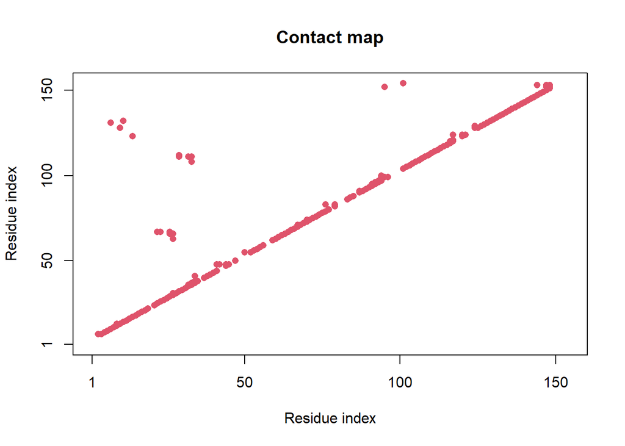

```r
pdbFile <- read.pdb("101M.pdb")

index <- pdbFile %>%
  atom.select(., "calpha")

cmap(pdbFile$xyz[index$xyz],
       dcut = 6, scut = 3) %>%
  plot.cmap(.)
```

> Conclusion

There are more different techniques for studying and obtaining various biomolecular structures. But among all of them the most utilized nowadays is the x-ray diffraction technique of the crystalazed molecules. Not only this technique produces the most accurate results, but it’s also relatively cheaper and easier tha other experimental techniques (e.g electron microscopy). The understeanding of the sequence of aminoacids of a protein and their position in space is the first step of modeling and determining the secondary structure of that protein; this is a crucial step also for the development of the majority of today’s drugs, since the main objective is to inhibit the protein by designing a ligand that can efficiently bind to the active site. And to do that we have to know precisely the structure of the protein itself.